# Predictive Modeling

Abiyu Giday

May 19, 2016

> “If we rely on intuitions of doubtful validity, we run a serious risk of making inaccurate predictions or over confidence decisions.” Joe Blitzstein

## Motivation

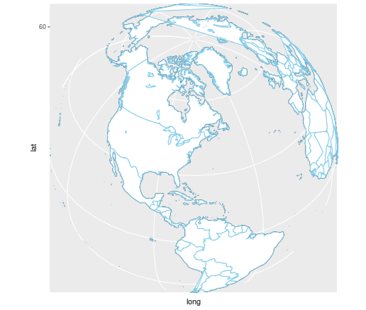

The adage *hind sight is 20/20* is often used to refer how we would have prepared differently had we known certain occurrences. Most of us, at one point or another, may have said ‘had I known x, I would have done y’. For example, had I known it was going to rain, I would have worn my rain jacket. Had I known event x happened with my customer, I would have given him this option or discount, or chosen this route. This ‘given this, then that’ scenario simulation is possible if we consider, what is known in the statistics world, [conditional probability](https://en.wikipedia.org/wiki/Conditional_probability). Applying ‘conditional probability’ increases accuracy to our response by noticeable magnitude. **“Conditional probability tells us how to update our belief in light of a new evidence that comes in.”[2]** Therefore, applying conditional statistics, based on actual data, will give us our best chance to understand and make decisions that are important.

On this blog I will cover how we can use *statical regression analysis to predict* an outcome that can be used to make inference. We will look at real world example from a real world dataset. Using a least square linear fitted regression, to demonstrate a relationship between geolocation(independent variable) and temperature (dependent) variable. We will first generate the dataset from three data sources and discuss the tidy process, followed by exploring and visualizing the data, and finally generating, evaluating and validating the model. Ultimately, we will use the model to predict temperature, given the latitude of a given location in the US.

## Scenario

[figure not shown]

Suppose, for example, a farmer in the United States (US) decides to grow coffee instead of corn, and he learned that one of the key ingredients in successful coffee farming is optimal seasonal temperature (We will use the month of April, as the start of spring which is ideal plant coffee). The farmer wants to decide on a location to buy a farm. He learned that [National Oceanic and Atmospheric Adminstration - NOAA](http://www.ncdc.noaa.gov/) keeps historical weather information for all major cities in the US, and wants to simulation model that will help him identified areas that he would consider for purchase. In short, he want to plug in latitude of location, and gets back temperature for that geolocation.

## Explore the data

The first order of business, as always, is to obtain data that will help extract temperature data in the US. NOAA collects and archives weather data from around the US. So we will be using the seasonal monthly average temperature dataset for 116 major US cities found [here](http://www.infoplease.com/ipa/A0762183.html), and merge it with the US cities geolocation dataset found in the `maps` package, to get our tidy data set for this analysis. Will not discuss how to tidy the data but the code is is located on [my github repository](https://github.com/abiyug/regression).

The resulting table is displayed here using the datatable function from ‘Data Table’ package.

|  | city | state | region | jan | apr | jul | oct | lat | long | popln |
| --- | --- | --- | --- | --- | --- | --- | --- | --- | --- | --- |
| 1 | honolulu | HI | West | 73 | 75.6 | 80.8 | 80.2 | 21.32 | -157.8 | 386345 |
| 2 | miami | FL | South | 68.1 | 75.7 | 83.7 | 78.8 | 25.78 | -80.21 | 386740 |
| 3 | tampa | FL | South | 61.3 | 71.5 | 82.5 | 75.8 | 27.96 | -82.48 | 328578 |
| 4 | san antonio | TX | South | 50.3 | 68.6 | 84.3 | 70.7 | 29.46 | -98.51 | 1278171 |
| 5 | houston | TX | South | 51.8 | 68.5 | 83.6 | 70.4 | 29.77 | -95.39 | 2043005 |
| 6 | new orleans | LA | South | 52.6 | 68.2 | 82.7 | 70 | 30.07 | -89.93 | 454207 |
| 7 | austin | TX | South | 50.2 | 68.3 | 84.2 | 70.6 | 30.31 | -97.75 | 683404 |
| 8 | jacksonville | FL | South | 53.1 | 66.6 | 81.6 | 69.4 | 30.33 | -81.66 | 809874 |
| 9 | baton rouge | LA | South | 50.1 | 66.6 | 81.7 | 68.1 | 30.45 | -91.13 | 222217 |
| 10 | mobile | AL | South | 50.1 | 66.1 | 81.5 | 67.7 | 30.68 | -88.09 | 188467 |

[output cut: 106 more lines]

*Table 1: US major cities seasonal average monthly temprature. Source NOAA.*

## Visualizing the data

Before any further analysis, we are going to visualize and see if any information can be gleaned from it. The following R graphics packages were used `ggplot2, leaflet and plotly`. **The graphs is interactivce.** By clicking on the data point and drilling down, once can see the average monthly temperature for all of the major cities in the US.

[interactive chart not shown]

*Figure 1: Interactive 116 US major cities and their respective monthlyaverage temprature*

Before even starting the statistical analysis, from the table and the map (click around different cities), we can observe that the average temperature generally warmer in south and south west vs the Midwest or east, for instance.

Now, lets get to the fun part and look start by looking at the scatter plot for lat/temp and fit a curve to the data. There are different kinds of curves to fit to the data besides linear - there are quadratic, cubic, quadratic, nth-degree and so on, the curve that will be selected depends on the scatter data pattern. On this case we are going to start with the linear (straight line) regression line.

## Modeling with Regression Analysis

Because the surface temperature on earth, is often, depends on geolocation measured by latitude and longitude, and this information is not influenced by temperature,we will use the latitude data as explanatory variable (x axis), the temperature as response variable (y-axis) for scattered plot. To generate the linear plot on the graph, we will use R’s linear model function (lm) to fit the Least [Squared Regression (LSR)](http://www.itl.nist.gov/div898/handbook/pmd/section1/pmd141.htm) line. LSR, also known as `goodness of fit` is how well the model fits the set of observed data.

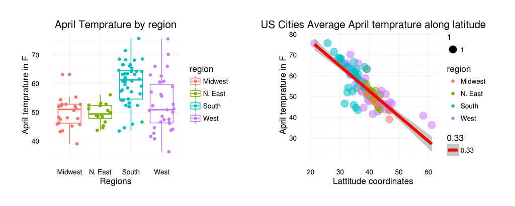

*Figure 2: The Figure on the left shows the boxplot temperature frequency distributions for each of the 4 regions in the US. The figure on the right shows linear model fit that shows negative correlation between latitude and temperature. As temperature decreases the latitude increases.*

### Fitting the Linear regresion model

A regression analysis gives an output that lists statistical relationships between predictor variable (latitude) and the response variable (temperature). The more significant outputs, for this example, that validate the model fit, including *residual error*, *$R^2$*, and *p-value*, will be discussed below.

To generate a model, we use the *linear model* (lm) function in `R` to carry out the regression single stratum analysis, to produce an equation we will use for prediction. **Which is the model will give us an estimation for temprature given the value for latitude.**

```r
attach(us_weather_df)
regression.lm <- lm(apr ~ lat)
regression.lm
```

```
##
## Call:
## lm(formula = apr ~ lat)
##
## Coefficients:
## (Intercept)          lat
##     100.761       -1.204
```

The value for the `cofficient` gives the values for the intercept `101` and the slope `-1.2` for the fitted regression line.

Therefore, the model equation we will use to predict temperature can be written as follows:

$Y = a_0 + a_1 X$ (1)

Or can be written on our case

$Temprature = 101 - 1.2 lat$ (2)

Plugging a latitude values range between 21.32, 61.18 to get temperature prediction. Now, before we confirm this is the model we will use we need to evaluate and validate our model.

## Evaluating our model

We will be using R `summary` function to look at the various model assumptions and evaluate how well our model fits the data. We will use the `summary` function to view the regression model.

```r
summary(regression.lm)                          # summary of the regression model
```

```
##
## Call:
## lm(formula = apr ~ lat)
##
## Residuals:
##      Min       1Q   Median       3Q      Max
## -16.1492  -2.3871   0.4762   2.5654  10.2127
##
## Coefficients:
##              Estimate Std. Error t value Pr(>|t|)
## (Intercept) 100.76093    3.04397   33.10   <2e-16 ***
## lat          -1.20366    0.07849  -15.34   <2e-16 ***
## ---
## Signif. codes:  0 '***' 0.001 '**' 0.01 '*' 0.05 '.' 0.1 ' ' 1
##
## Residual standard error: 4.812 on 114 degrees of freedom
## Multiple R-squared:  0.6735, Adjusted R-squared:  0.6706
## F-statistic: 235.2 on 1 and 114 DF,  p-value: < 2.2e-16
```

There are lots of information to parse here, but the once we are interested for evaluating and validating our models are residual error, p value, $R^2$, and the coefficients (which was covered earlier).

### Residual Error

Residual error, in statistics, are referred to the `true` error and the plots will measure of the variation in the response variable (temp) due to error. Before we validate our model and give it thumbs up, we must check the `residual error` plot. If the plot shows no discernible pattern, then it is considered the model assumption is accepted. If there is pattern in the error plot, there is flow and we need to remodel with different fitted line.

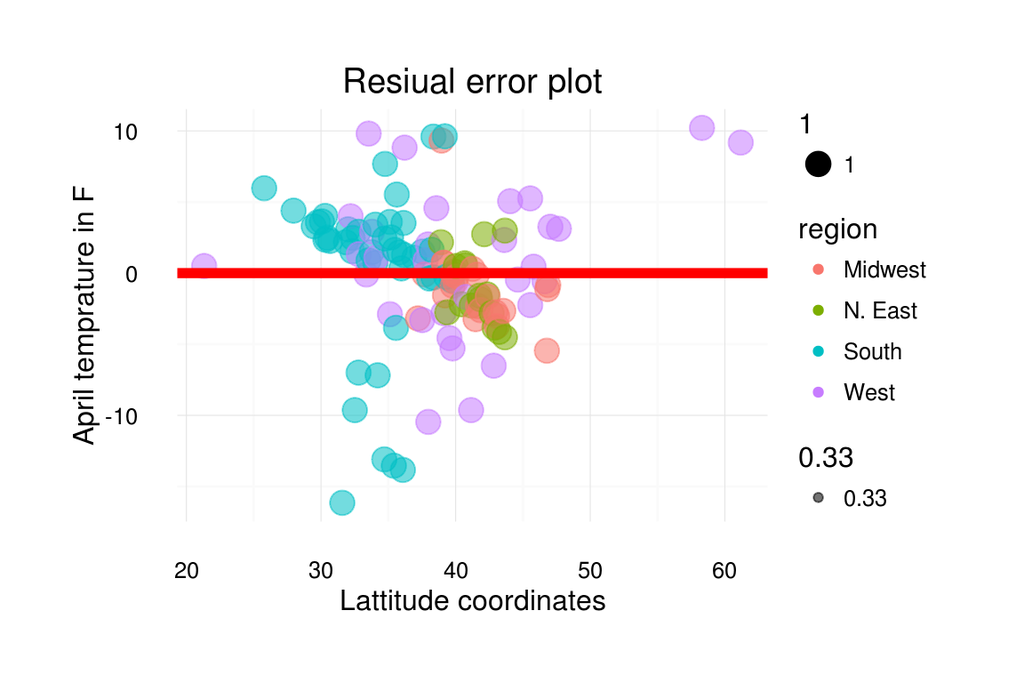

**_Figure 3: Because the resulting plot shows the “random residual error patterns”“, we can confirm that the model is systematically correct for the fitted values! Otherwise, we can go back to plotting another least squared linear line to help improve the model._**

### $R^2$ Goodness of fit measure

I The formal definition of $R^2$ is “the percentage of variation in the response that is explained by the model”. Generally, the higher the $R^2$ value the better the fit to the data, the tighter the scatter plots are around the line, which indicates a higher correlation between the predictor (lat) and the response(temp). n our model we see that $R^2$ value is `0.67` which is acceptable for our purposes.

### p value

The P value for bot the intercept and the slope is tests a null hypothesis that the coefficient is equal to zero or it has no effect. A good indication for a change in latitude is related to a change in temperature.

```r
coef(summary(regression.lm))                           # extract standard error, t-value, p-value
```

```
##               Estimate Std. Error   t value     Pr(>|t|)
## (Intercept) 100.760933 3.04396595  33.10186 2.654059e-60
## lat          -1.203664 0.07848957 -15.33534 1.765463e-29
```

Because p-value $2.65^-60$ and $1.76^-29$ are both less than 0.05, we reject a null hypothesis. Which means predictor **is very likely an meaningful contributor to our model**.

## Prediction

If we input the latitude into the model, we can now use our model to predict the temperature. The weather data is only for the US only. For example, if we want see what the temperature for latitude 25 and 55 degrees, we can do the following.

```r
new_lat <- data.frame(lat = c(25, 55))                    # New latitude to get temp prediction for
pred <- predict(regression.lm, new_lat)                   # use the model to predict temp
df1 <- cbind(latitude = new_lat, Predicted_Temp = pred)   # combine the result for display
#DT::datatable(round(df1, 2))
df1
```

```
##   lat Predicted_Temp
## 1  25       70.66934
## 2  55       34.55942
```

## Checking confidence for our predction

When using a mode it is more appropriate to give a range or interval for the predicted temperature rather than a single value, due to margin of error consideration. Therefore, we will use the confidence interval option in the predict function, to get temperature values in 95% confidence interval range for a given set of latitude. Here is an example.

|  | lat | fit | lwr | upr |
| --- | --- | --- | --- | --- |
| 1 | 21 | 75.48 | 72.64 | 78.32 |
| 2 | 28 | 67.06 | 65.22 | 68.9 |
| 3 | 34 | 59.84 | 58.72 | 60.95 |
| 4 | 49.3 | 41.42 | 39.5 | 43.34 |
| 5 | 52.2 | 37.93 | 35.6 | 40.26 |
| 6 | 60.1 | 28.42 | 24.93 | 31.91 |

*Table 2: The table can be explained as follows:- for 21 degree latitude, in the month of April, on average, the temperature is between 72.6 and 78.3 degree Fahrenheit.*

## Take Away

Here we have seen that given historical temperature data and the geolocation coordinate data, we have demonstrated linear relationship, and generated a model that will predict reasonable temperature given the latitude within the US.

*Note: The model can be embeded in a a web app and be made avialble to other farmers. Perhaps I will develop and share the app using a RStudio shiny frame work.*

## Code

[The full program and data for this paper is found on my github respository]((https://github.com/abiyug/regression)

## References

[1] (US Department of commerce)[http://www.itl.nist.gov/div898/handbook/pmd/section1/pmd141.htm] *Engineering Statstics handbook*  
[2J J. Blitzstein and J. Hawang - *Introduction to Probability*, CRC press  
[3] B. Caffo *Regression Models for Data Science in R* JHU lean pub  
[4] G. Hystadd lecture *Simple Linear Regerssion*  
[5] Weather data is obtained from from National Oceanic & Atmospheric Administration (NOAA)

**This document is fully reproducible**